# ML With R (3): Logistic Regression

2016-09-21 7:37 am | Comments

**Code in R for [Coursera-ML](https://www.coursera.org/learn/machine-learning) and [CMPUT466/551](https://www.ualberta.ca/computing-science/undergraduate-studies/course-directory/courses/machine-learning) in University of Alberta**

This post refers to programming exercise 2 in Coursera-ML. All the code can be found in [this repo](https://github.com/billy-inn/CourseraMLwithR).

```r
setwd("~/Coding/R/CMPUT466/mlclass-ex2")
library(ggplot2)
library(R.matlab)
library(devtools)
source_url("https://raw.githubusercontent.com/ggrothendieck/gsubfn/master/R/list.R")
```

### Logistic Regression

#### Visualizing the data

Use a scatter plot to visualize the data.

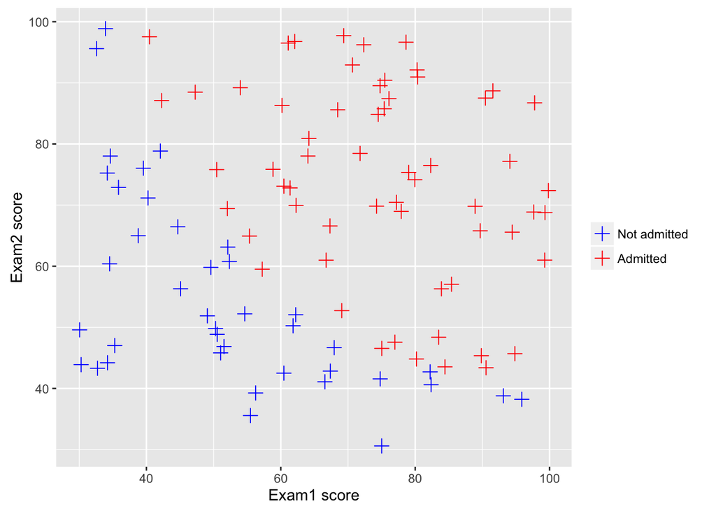

```r
data <- read.csv("ex2data1.txt", header=FALSE)
X <- as.matrix(data[,c("V1", "V2")])
y <- as.matrix(data$V3)
ggplot(data, aes(x=V1, y=V2, col=factor(V3))) +
  geom_point(shape=I(3), size=I(3)) +
  labs(x="Exam1 score", y="Exam2 score") +
  scale_color_manual(name="", labels=c("Not admitted", "Admitted"), values = c("blue", "red"))
```

#### Cost function and gradient

The cost function in logistic regression is

$$J(\theta)=\frac1m\sum_{i=1}^m[-y^{(i)}\log(h_\theta(x^{(i)}))-(1-y^{(i)})\log(1-h_\theta(x^{(i)}))],$$

and the gradient of the cost is a vector of the same length as $\theta$ where the $j^{th}$ element (for $j=0,1,\dots,n$) is defined as follows:

$$\frac{\partial J(\theta)}{\partial \theta_j}=\frac1m\sum_{i=1}^m(h_\theta(x^{(i)})-y^{(i)})x_j^{(i)}$$

```r
costFunction <- function(theta, X, y) {
  m <- length(y)
  h <- 1./(1+exp(-X %*% theta))
  J <- 1./m * (-t(y) %*% log(h) - t(1-y) %*% log(1-h))
  grad <- 1./m * t(X) %*% (h-y)
  list(J, grad)
}

m <- dim(X)[1]
n <- dim(X)[2]
X <- cbind(1, X)
initial_theta <- matrix(0, n+1, 1)

list[cost, grad] = costFunction(initial_theta, X, y)
cost
```

```
##           [,1]
## [1,] 0.6931472
```

#### Learning parameters

Use the `optim` function choosing BFGS (in order to do unconstrainted optimization) to fit the logistic regression and plot the decision boundary.

```r
computeCost <- function(theta, X, y) {
  m <- length(y)
  h <- 1./(1+exp(-X %*% theta))
  1./m * (-t(y) %*% log(h) - t(1-y) %*% log(1-h))
}
computeGrad <- function(theta, X, y) {
  m <- length(y)
  h <- 1./(1+exp(-X %*% theta))
  1./m * t(X) %*% (h-y)
}
res <- optim(initial_theta, computeCost, computeGrad, X, y, method="BFGS", control=list(maxit = 400))
theta <- res$par
computeCost(theta, X, y)
```

```
##           [,1]
## [1,] 0.2034985
```

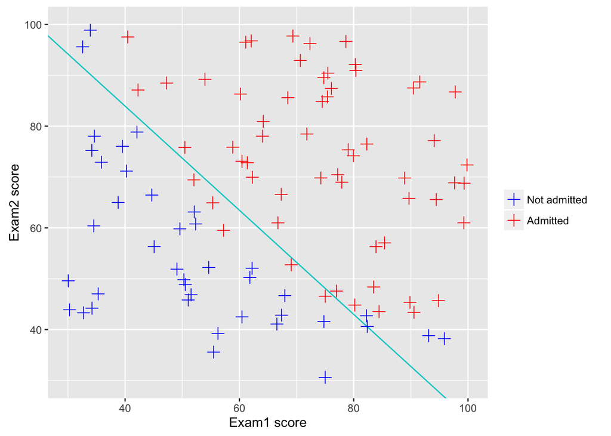

```r
plot_x <- c(min(X[,2])-10, max(X[,2])+10)
plot_y <- (-1./theta[3]) * (theta[2] * plot_x + theta[1])
df_db <- data.frame(x=plot_x, y=plot_y)
ggplot(df_db, aes(x,y)) + geom_line(color="cyan3") +
  geom_point(aes(V1, V2, col=factor(V3)), data, size=I(3), shape=I(3)) +
  labs(x="Exam1 score", y="Exam2 score") +
  scale_color_manual(name="", labels=c("Not admitted", "Admitted"), values = c("blue", "red")) +
  coord_cartesian(xlim=c(30, 100), ylim=c(30, 100))
```

#### Evaluating logistic regression

```r
sigmoid <- function(x) 1./(1+exp(-x))
prob <- sigmoid(c(1, 45, 85) %*% theta)
prob
```

```
##           [,1]
## [1,] 0.7756949
```

```r
y_prob <- sigmoid(X %*% theta)
p <- y_prob > 0.5
mean(p==y) * 100.0
```

```
## [1] 89
```

### Regularized Logistic Regression

#### Visualizing the data

Use a scatter plot to visualize the data.

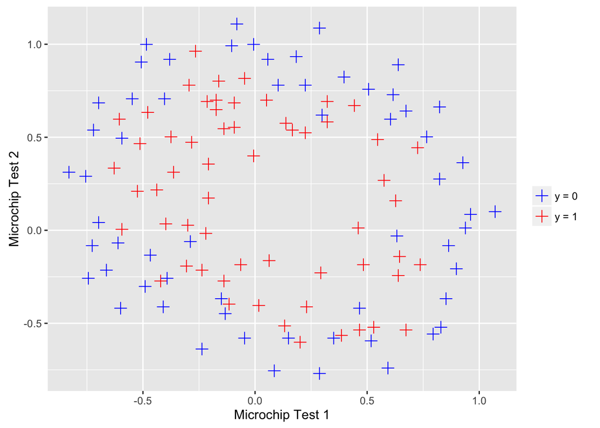

```r
data <- read.csv("ex2data2.txt", header=FALSE)
X <- as.matrix(data[,c("V1", "V2")])
y <- as.matrix(data$V3)
ggplot(data, aes(x=V1, y=V2, col=factor(V3))) +
  geom_point(shape=I(3), size=I(3)) +
  labs(x="Microchip Test 1", y="Microchip Test 2") +
  scale_color_manual(name="", labels=c("y = 0", "y = 1"), values = c("blue", "red"))
```

#### Feature mapping

One way to fit the data better is to create more features from each data point. Here we map the features into all polynomial terms of $x_1$ and $x_2$ up to the sixth power. As a result of this mapping, our vector of features has been transformed into a $28$-dimensional vector.

```r
mapFeature <- function(X1, X2) {
  degree <- 6
  out <- matrix(1, length(X1), 1)
  for(i in 1:6) {
    for(j in 0:i) {
      out <- cbind(out, (X1^(i-j)) * (X2^j))
    }
  }
  out
}
X <- mapFeature(X[,1], X[,2])
```

#### Cost function and gradient

Note that you should not regularize the parameter $\theta_0$. The gradient of the cost is a vector where the $j^{th}$ element (for $j=0,1,\dots,n$) is defined as follows:

$$\begin{split}
&\frac{\partial J(\theta)}{\partial \theta_0}=\frac1m\sum_{i=1}^m(h_\theta(x^{(i)})-y^{(i)})x_j^{(i)} & \mathrm{for}\ j=0\\
&\frac{\partial J(\theta)}{\partial \theta_j}=\left(\frac1m\sum_{i=1}^m(h_\theta(x^{(i)})-y^{(i)})x_j^{(i)}\right) + \frac{\lambda}m\theta_j \quad&\mathrm{for}\ j\ge1
\end{split}$$

```r
costFunctionReg <- function(theta, X, y, lambda) {
  m <- length(y)
  h <- 1./(1+exp(-X %*% theta))
  theta0 <- theta
  theta0[1] <- 0
  J <- 1./m*(-t(y) %*% log(h) - t(1-y) %*% log(1-h)) + lambda/(2*m)*t(theta0)%*%theta0
  grad <- 1./m*t(X) %*% (h-y) + lambda/m*theta0
  list(J, grad)
}
initial_theta <- matrix(0, dim(X)[2], 1)
lambda <- 1
list[cost, grad] <- costFunctionReg(initial_theta, X, y, lambda)
cost
```

```
##           [,1]
## [1,] 0.6931472
```